# Homework 7. `numpy`

Here you can find the solution of the homework 7 of the 'Herramientas computacionales' course at uniades (Section 6) [Course](https://github.com/jmsevillam/Herramientas-Computacionales-UniAndes), [Homework](https://github.com/jmsevillam/Herramientas-Computacionales-UniAndes/blob/master/Homework/Hw7/Hw7.pdf).

As we are going to use `numpy`, we import it to use `numpy.array` structure,

```python
import numpy as np
```

Create an `array` from $0$ to $10$ including the limits,

```python
x=np.linspace(0,10,1000)
```

It has the expected lenght

```python
len(x)
```

```
1000
```

We create some noisy signal by adding random numbers to a sine function,

```python
y=np.sin(x)+(0.4*(np.random.random(len(x))-0.2))
```

We use `matplotlib` as auxiliar visualization,

```python
import matplotlib.pylab as plt
```

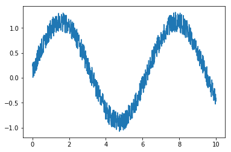

```python
plt.plot(x,y)
plt.savefig('fig1.pdf')
plt.show()
```

We use some of the numpy built-in functions to find the mean, variance, maximum and minimum.

```python
np.mean(y)
```

```
0.29902630965512633
```

```python
np.var(y)
```

```
0.4522265938880142
```

```python
np.max(y)
```

```
1.3145964014080123
```

```python
np.min(y)
```

```
-1.0743402522984065
```

In order to get the value of $x$ in which $y$ is max, we use the function `numpy.argmax`

```python
np.argmax(y)
```

```
778
```

And we use it to get the x of that cellm

```python
x[np.argmax(y)]
```

```
7.787787787787788
```

We implement two different ways to calculate the variance and average, one is based on the `list` structure and the other using the `numpy` structure.

The skewness and Kurtosis functions are made by using the `numpy` structure.

```python
def variance(x):
    ave=average(x)
    suma=0.
    for i in range(len(x)):
        suma+=(x[i]-ave)**2
    suma/=len(x)
    return suma
```

```python
def variance2(x):
    ave=average2(x)
    suma=np.sum((x-ave)**2.)/len(x)
    return suma
```

```python
def average(x):
    suma=0.
    for i in range(len(x)):
        suma+=x[i]
    suma=suma/len(x)
    return suma
```

```python
def average2(x):
    suma=np.sum(x)/len(x)
    return suma
```

```python
def skewness(x):
    ave=average2(x)
    suma=np.sum((x-ave)**3.)/len(x)
    return suma
```

```python
def Kurtosis(x):
    ave=average2(x)
    suma=np.sum((x-ave)**4.)/len(x)
    return suma
```

We use them,

```python
%time
average(y)
```

```
CPU times: user 3 µs, sys: 0 ns, total: 3 µs
Wall time: 5.96 µs
```

```
0.2990263096551267
```

```python
%time
average2(y)
```

```
CPU times: user 2 µs, sys: 1 µs, total: 3 µs
Wall time: 6.2 µs
```

```
0.29902630965512633
```

```python
%time
variance(y)
```

```
CPU times: user 3 µs, sys: 0 ns, total: 3 µs
Wall time: 5.96 µs
```

```
0.45222659388801456
```

```python
%time
variance2(y)
```

```
CPU times: user 3 µs, sys: 1 µs, total: 4 µs
Wall time: 5.72 µs
```

```
0.4522265938880142
```

```python
%time
np.var(y)
```

```
CPU times: user 3 µs, sys: 1 µs, total: 4 µs
Wall time: 5.01 µs
```

```
0.4522265938880142
```

```python
skewness(y)
```

```
-0.11617066301547643
```

```python
Kurtosis(y)
```

```
0.3829253953325561
```

We use again `matplotlib`to see the *distribution* of the $y$ points,

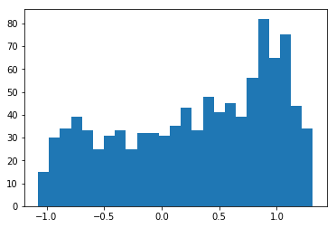

```python
plt.hist(y,bins=25)
plt.savefig('fig2.pdf')
plt.show()
```

We perform some transformations on the data,

```python
y2=np.sort(y)
```

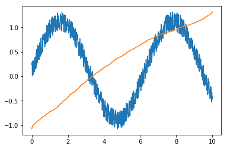

```python
plt.plot(x,y)
plt.plot(x,y2)
plt.savefig('fig3.pdf')
plt.show()
```

[output not shown]

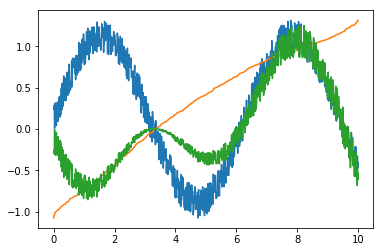

```python
y3=y*y2
plt.plot(x,y)
plt.plot(x,y2)
plt.plot(x,y3)
plt.savefig('fig4.pdf')
plt.show
```

And we calculate the percentile 5 and 95

```python
np.percentile(y3,q=[5,95])
```

```
array([-0.67891694,  1.03440143])
```